# TVIMS_DZ5_Smyslovskikh

Елена Смысловских

8/04/2020

## Задание 1

```r
library(readstata13)
library(fs)
library(haven)
library(psych)
library(dplyr)
library(ggplot2)
library(GGally)
library(car)
library(memisc)
library(knitr)
opts_chunk$set(fig.align = 'center')
```

```r
df <- read.dta13("https://politologi-tvims2.github.io/hw15.dta")
df <- dplyr::select(df, c(ch_schools_pc, afreq, nozemstvo, distance_moscow, goodsoil, lnurban, lnpopn, province_capital))
head(df)
```

```
##   ch_schools_pc      afreq nozemstvo distance_moscow  goodsoil  lnurban
## 1     0.2357934 0.07692308         1       1.0683093 0.2536144 9.912397
## 2     0.2354524 0.00000000         1       1.2823936 0.2335225 7.696213
## 3            NA         NA        NA              NA        NA       NA
## 4     0.2177528 0.00000000         1       1.3208637 0.1823315 7.465655
## 5     0.2355296 0.00000000         1       0.8862297 0.2062453 7.507690
## 6            NA 0.00000000         1       1.6973912 0.1482677       NA
##     lnpopn province_capital
## 1 10.93069                1
## 2 10.43828                0
## 3       NA               NA
## 4 10.64032                0
## 5 10.38264                0
## 6       NA                0
```

Уже из шапки данных мы видим, что в них есть пропуски. Избавимся от них.

```r
df <- na.omit(df)
```

Теперь построим регрессионную модель и оценим ее.

```r
mod1 <- lm(ch_schools_pc ~ afreq + nozemstvo + distance_moscow + goodsoil + lnurban + lnpopn + province_capital, data = df)
summary(mod1)
```

```
##
## Call:
## lm(formula = ch_schools_pc ~ afreq + nozemstvo + distance_moscow +
##     goodsoil + lnurban + lnpopn + province_capital, data = df)
##
## Residuals:
##      Min       1Q   Median       3Q      Max
## -0.33848 -0.09634 -0.03551  0.04695  1.45921
##
## Coefficients:
##                   Estimate Std. Error t value Pr(>|t|)
## (Intercept)       0.683238   0.218271   3.130 0.001853 **
## afreq            -0.181470   0.054400  -3.336 0.000916 ***
## nozemstvo         0.080091   0.021793   3.675 0.000264 ***
## distance_moscow  -0.012096   0.031894  -0.379 0.704660
## goodsoil         -0.008286   0.023997  -0.345 0.730028
## lnurban           0.013287   0.007274   1.827 0.068371 .
## lnpopn           -0.042304   0.019890  -2.127 0.033937 *
## province_capital  0.040362   0.030172   1.338 0.181621
## ---
## Signif. codes:  0 '***' 0.001 '**' 0.01 '*' 0.05 '.' 0.1 ' ' 1
##
## Residual standard error: 0.1782 on 481 degrees of freedom
## Multiple R-squared:  0.1018, Adjusted R-squared:  0.08873
## F-statistic: 7.788 on 7 and 481 DF,  p-value: 6.081e-09
```

**Интерпретация:**

- При увеличении доли лет с 1851 до 1863 года, в течение которых были зафиксированы крестьянские выступления, на 1 единицу измерения, *ch_schools_pc* (количество школ на душу сельского населения уезда) в среднем и при прочих равных снизится на величину, равную 0.181470.
- При условии того, что в результате реформы 1864 года земство создано не было, количество школ на душу сельского населения уезда в среднем и при прочих равных увеличится на 0.080091.
- При условии того, что все предикторы равны 0, количество школ на душу сельского населения уезда принимает значение 0.683238.

**Теоретические основания предполгать наличие гетероскедастичности:**

- Во-первых, вполне возможно, в модель ошибочно заложена линейная взаимосвязь, в то время как на самом деле она может быть нелинейной (например, количество школ на душу сельского населения уезда может расти, если восстаний было немного (что говорит о гражданском потенциале), и убывать, если их было слишком много и регион сильно пострадал в результате этого вместе со всей инфраструктурой)
- Во-вторых, мы можем иметь скошенное распределение по какой-либо из переменных, и в данном случае логично предполагать скошенность распределения переменной *afreq* , поскольку потенциал уезда к крестьянским выступлениям скорее всего будет зависеть от истории выступлений в прошлом, а также от общей тенденции населения к коллективному действию. Таким образом, можно предположить, что доля лет, в которые происходили крестьянские выступления, будет распределена неравномерно, и в отдельных регионах будет завышена по сравнению с остальными.

Проверим на графике:

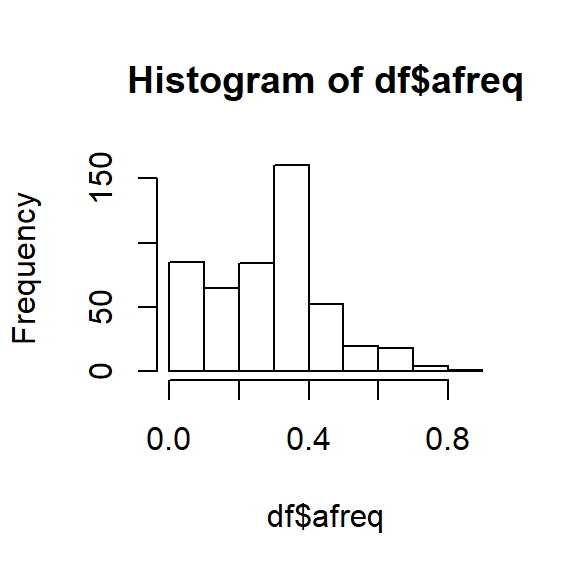

```r
hist(df$afreq)
```

Действительно, мы видим, что в основной массе уездов крестьянские выступления происходили не более, чем в половине лет за изучаемый период, при этом есть более редкие случаи, в которых доля лет, в которые происходили крестьянские вытспуления, составляет от 0.5 до 0.8.

- Мы можем иметь дело с влиятельными наблюдениями, что скорее всего произойдет, поскольку отдельные регионы (и все уезды в них) могут быть важными урбанизированными территориями или иметь повышенное финансирование, соответственно, в них будет строиться больше школ.
- Данные взяты из разных источников, что может исказить распределение ошибок для каких-то определенных показателей, а это может привести к гетероскедастичности в модели.
- Наконец, мы могли пропустить какой-то значимый показатель и наоборот, включить неверный: например, у меня есть сомнения по поводу того, насколько предиктор *goodsoil* (показатель плодородности почвы) влияет на изменение в количестве школ на душу сельского населения уезда. Возможно, он был взят в качестве прокси на экономическое благосостояние уезда, однако учитывая, что промышленный переворот в России начался в 30-40-е годы XIX века и завершился в 1880-х, то скорее всего, эта переменная не годится для модели.

## Задание 2

```r
library(sandwich)
```

1. Посмотрим на **визуализацию**.

Рассмотрим распределение показателей:

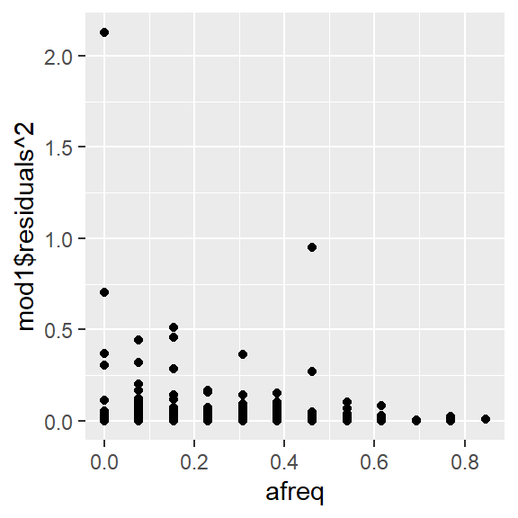

```r
ggplot(mod1, aes(afreq, mod1$residuals^2)) + geom_point()
```

На некоторых участках распределения мы можем наблюдать выбросы,т.е. в некоторых уездах было зафиксировано аномально большое количество школ на душу населения.

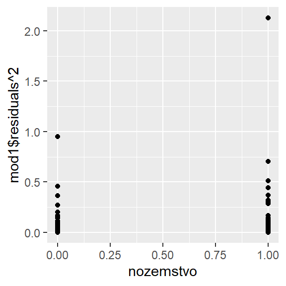

```r
ggplot(mod1, aes(nozemstvo, mod1$residuals^2)) + geom_point()
```

В случае, если земство создано не было, мы наблюдаем менее однородное распределение, однако в обоих случаях есть выбросы среди наблюдений.

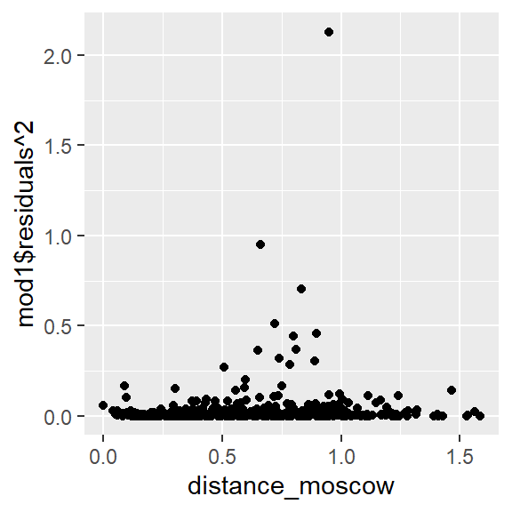

```r
ggplot(mod1, aes(distance_moscow, mod1$residuals^2)) + geom_point()
```

Есть выбросы.

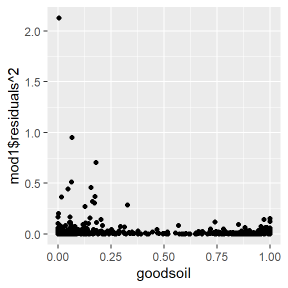

```r
ggplot(mod1, aes(goodsoil, mod1$residuals^2)) + geom_point()
```

Переменая *goodsoil* имеет скошенное распределение: очень мало наблюдений со средними значениями, а также есть выбросы.

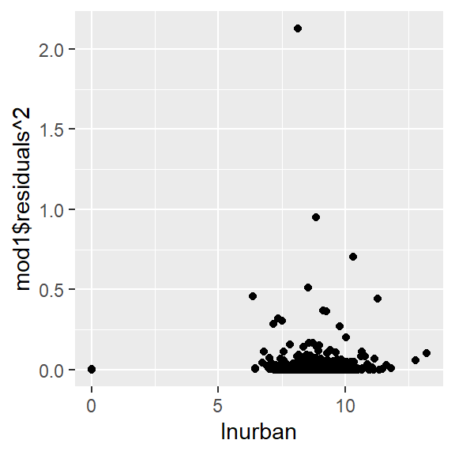

```r
ggplot(mod1, aes(lnurban, mod1$residuals^2)) + geom_point()
```

Мы видим, что в случае переменной *lnurban* мы имеем дело с нетипичными значениями, которые сильно отклоняются от среднего, то есть, *leverage*.

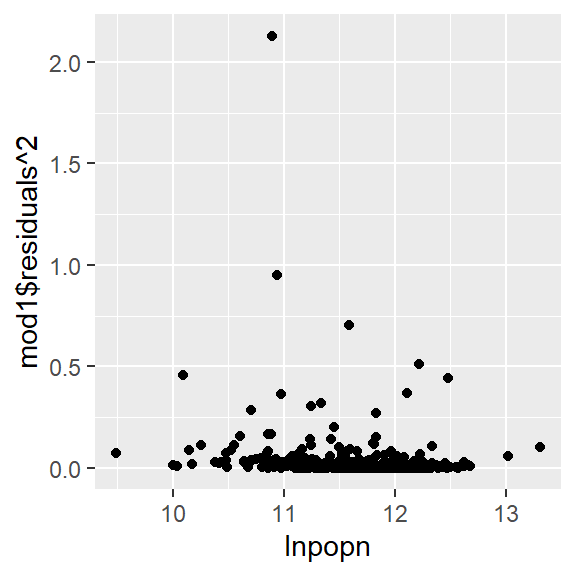

```r
ggplot(mod1, aes(lnpopn, mod1$residuals^2)) + geom_point()
```

Переменная *lnpopn* имеет несколько выбросов.

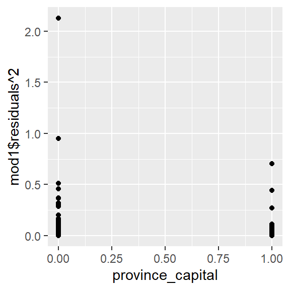

```r
ggplot(mod1, aes(province_capital, mod1$residuals^2)) + geom_point()
```

Теперь посмотрим на распределение квадратов остатков по всем предикторам:

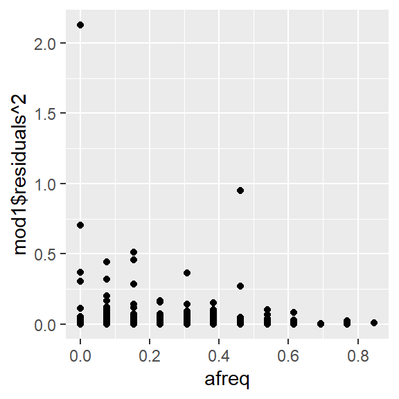

```r
ggplot(mod1, aes(afreq, mod1$residuals^2)) + geom_point()
```

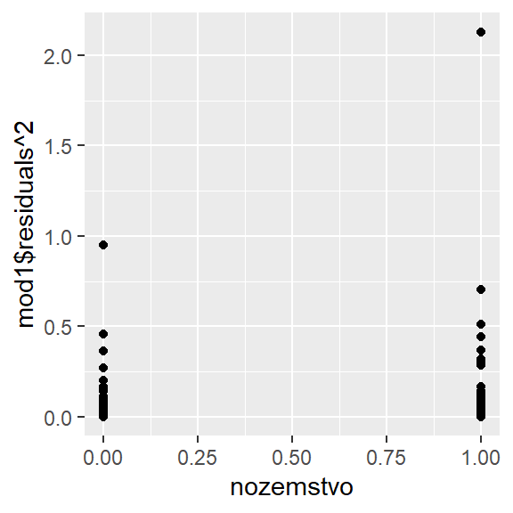

```r
ggplot(mod1, aes(nozemstvo, mod1$residuals^2)) + geom_point()
```

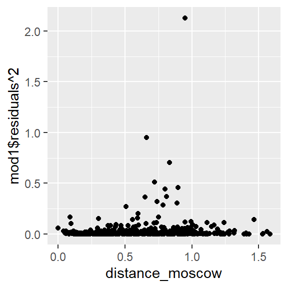

```r
ggplot(mod1, aes(distance_moscow, mod1$residuals^2)) + geom_point()
```

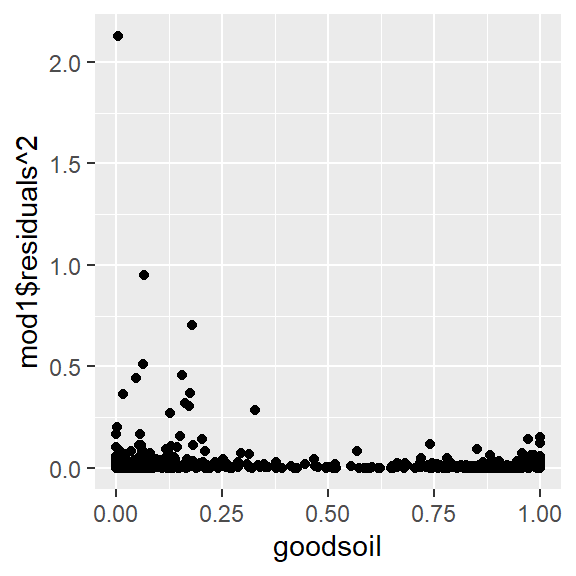

```r
ggplot(mod1, aes(goodsoil, mod1$residuals^2)) + geom_point()
```

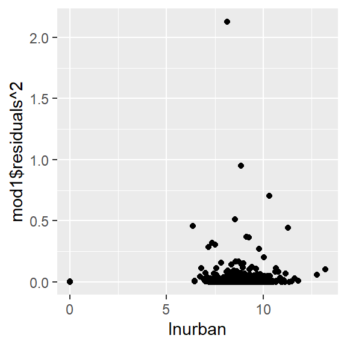

```r
ggplot(mod1, aes(lnurban, mod1$residuals^2)) + geom_point()
```

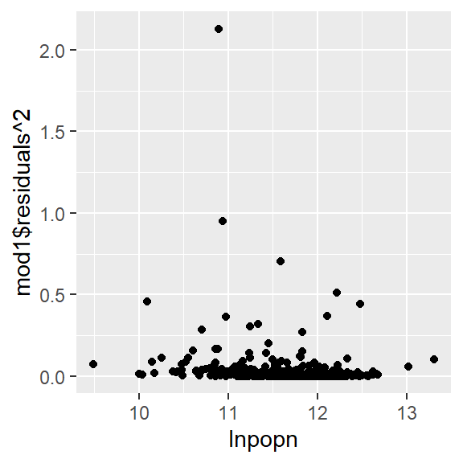

```r
ggplot(mod1, aes(lnpopn, mod1$residuals^2)) + geom_point()
```

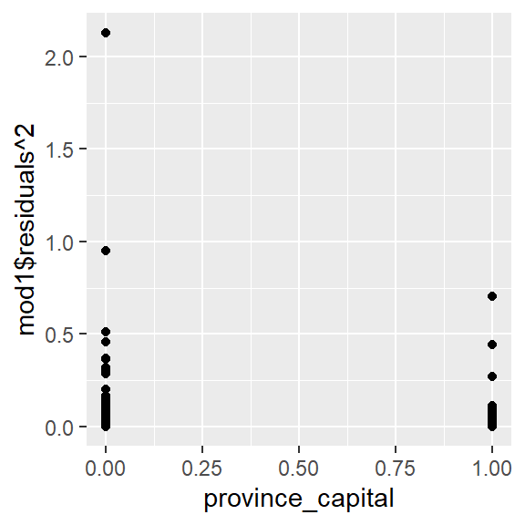

```r
ggplot(mod1, aes(province_capital, mod1$residuals^2)) + geom_point()
```

Наконец, посмотрим на линейную свертку модели (предсказанные значения):

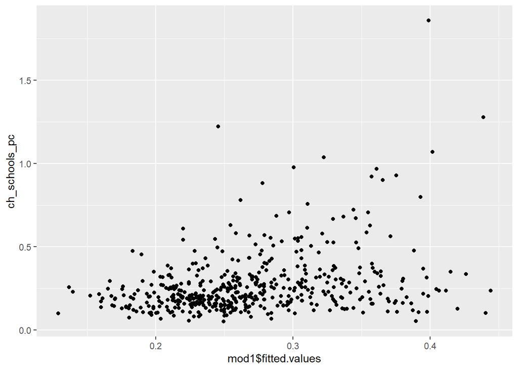

```r
ggplot(mod1, aes(mod1$fitted.values, ch_schools_pc)) + geom_point()
```

Из проделанной визуализации можно сделать вывод, что многие факторы дают нам основания предполагать наличие гетероскедастичности в модели в связи с неравномерностью распределения.

2. Теперь проведем формальный _тест Бреуша-Пагана__ для того, чтобы точно определить, страдает ли модель от гетероскедастичности.

```r
library(lmtest)
```

```r
bptest(mod1)
```

```
##
##  studentized Breusch-Pagan test
##
## data:  mod1
## BP = 33.11, df = 7, p-value = 2.526e-05
```

Тестируем нулевую гипотезу об отсутствии гетероскедастичности в модели. Мы видим, что значение *p-value* очень маленькое (<0.01, что меньше конвенционального уровня значимости), соответственно, у нас есть основания отвергнуть нулевую гипотезу, мы можем заявлять о возможном наличии гетероскедастичности.

3. Проведем тест **Goldfeld-Quandt** для каждого предиктора чтобы оценить, зависит ли разброс ошибок от конкретной переменной. В данном случае нулевая гипотеза снова будет об отсутствии гетероскедастичности.Для каждого теста проранжируем наблюдения по предиктору, затем оценим, насколько модель, из которой исклюены 20% наблюдений в середине выборки, будет отличаться от исходной модели.

```r
# afreq
gqtest(mod1, order.by = ~afreq, data = df, fraction = 0.2)
```

```
##
##  Goldfeld-Quandt test
##
## data:  mod1
## GQ = 0.37354, df1 = 188, df2 = 187, p-value = 1
## alternative hypothesis: variance increases from segment 1 to 2
```

*p-value* = 1, следовательно, у нас нет оснований отвергнуть нулевую гипотезу. То есть, данный тест не подтвердил наше предположение о том, что гетероскедастичность в модели присутствует из-за смещенного распределения доли лет, в которых случались крестьянские восстания.

```r
# nozemstvo
gqtest(mod1, order.by = ~nozemstvo, data = df, fraction = 0.2)
```

```
##
##  Goldfeld-Quandt test
##
## data:  mod1
## GQ = 3.0884, df1 = 188, df2 = 187, p-value = 2.825e-14
## alternative hypothesis: variance increases from segment 1 to 2
```

```r
# distance_moscow
gqtest(mod1, order.by = ~distance_moscow, data = df, fraction = 0.2)
```

```
##
##  Goldfeld-Quandt test
##
## data:  mod1
## GQ = 3.9175, df1 = 188, df2 = 187, p-value < 2.2e-16
## alternative hypothesis: variance increases from segment 1 to 2
```

По резульатам тестов, у нас есть основания отвергнуть нулевую гипотезу для предикторов *nozemstvo* и *distance_moscow*, так как *p-value* имеет низкое значение для всех разумных уровней значимости.

```r
# goodsoil
gqtest(mod1, order.by = ~goodsoil, data = df, fraction = 0.2)
```

```
##
##  Goldfeld-Quandt test
##
## data:  mod1
## GQ = 0.2353, df1 = 188, df2 = 187, p-value = 1
## alternative hypothesis: variance increases from segment 1 to 2
```

```r
# lnurban
gqtest(mod1, order.by = ~lnurban, data = df, fraction = 0.2)
```

```
##
##  Goldfeld-Quandt test
##
## data:  mod1
## GQ = 0.79213, df1 = 188, df2 = 187, p-value = 0.9443
## alternative hypothesis: variance increases from segment 1 to 2
```

```r
# lnpopn
gqtest(mod1, order.by = ~lnpopn, data = df, fraction = 0.2)
```

```
##
##  Goldfeld-Quandt test
##
## data:  mod1
## GQ = 0.40706, df1 = 188, df2 = 187, p-value = 1
## alternative hypothesis: variance increases from segment 1 to 2
```

```r
# province_capital
gqtest(mod1, order.by = ~province_capital, data = df, fraction = 0.2)
```

```
##
##  Goldfeld-Quandt test
##
## data:  mod1
## GQ = 0.62137, df1 = 188, df2 = 187, p-value = 0.9994
## alternative hypothesis: variance increases from segment 1 to 2
```

Для всех остальных переменных, с учетом того, что *p-value* близко к 1, у нас нет оснований отвергнуть нулевую гипотезу.

Исходя из результатов тестов, мы можем утверждать, что заявлять о гетероскедастичности мы можем только исходя из двух предикторов, а именно: отсутствия введенного земства и расстояния уезда до Москвы.

4. Поскольку на предыдущем шаге мы выявили гетероскедастичность по двум переменным, то попробуем переоценить стандартные ошибки.

```r
coeftest(mod1, vcov = vcovHC(mod1, "HC3"))
```

```
##
## t test of coefficients:
##
##                    Estimate Std. Error t value Pr(>|t|)
## (Intercept)       0.6832379  0.3202294  2.1336 0.033382 *
## afreq            -0.1814696  0.0620802 -2.9231 0.003628 **
## nozemstvo         0.0800914  0.0277828  2.8828 0.004118 **
## distance_moscow  -0.0120961  0.0313445 -0.3859 0.699735
## goodsoil         -0.0082858  0.0214809 -0.3857 0.699867
## lnurban           0.0132868  0.0048017  2.7671 0.005873 **
## lnpopn           -0.0423038  0.0285732 -1.4805 0.139383
## province_capital  0.0403619  0.0332855  1.2126 0.225880
## ---
## Signif. codes:  0 '***' 0.001 '**' 0.01 '*' 0.05 '.' 0.1 ' ' 1
```

Действительно, можно сказать, что результаты изменились. Предикторы *afreq* и *nozemstvo* потеряли в значимости, константа - тоже, а *lnpopn* и вовсе перестал быть значимым в модели. При этом коэффициенты остались стабильными.

## Задание 3

Теперь протестируем модель на влиятельные наблюдения.

1. Посмотрим на **взаимосвязь hat-values и Стьюдентизированных остатков**. Для этого построим графики:

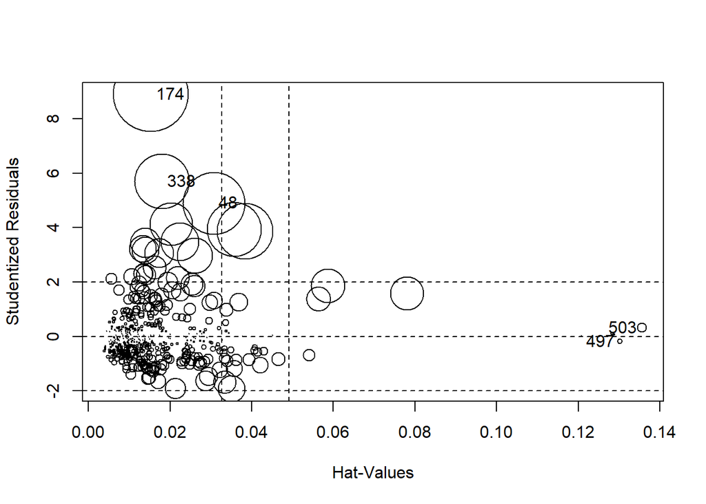

```
##        StudRes        Hat        CookD
## 48   4.8972367 0.03071043 0.0906512614
## 174  8.8951988 0.01528569 0.1320786297
## 338  5.7019856 0.01797537 0.0698165013
## 497 -0.1880245 0.13018841 0.0006627627
## 503  0.3223315 0.13561100 0.0020413191
```

```r
influencePlot(mod1)
```

```r
library(olsrr)
```

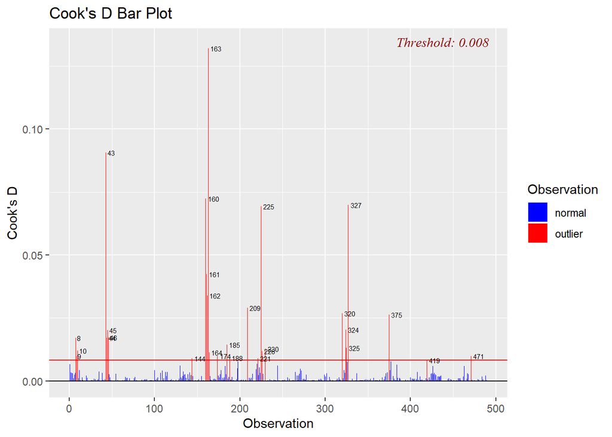

```r
ols_plot_cooksd_bar(mod1)
```

Нетипичные наблюдения могут значительно ухудшить результаты моделирования - они могут сделать оценки смещенными или неэффективными.

2. Попробуем переоценить модель без трех наиболее значимых наблюдений.

```r
dfnew <- df[-c(43, 163, 160), ]
mod2 <- lm(data = dfnew, ch_schools_pc ~ afreq + nozemstvo + distance_moscow + goodsoil + lnurban + lnpopn + province_capital)
summary(mod2)
```

```
##
## Call:
## lm(formula = ch_schools_pc ~ afreq + nozemstvo + distance_moscow +
##     goodsoil + lnurban + lnpopn + province_capital, data = dfnew)
##
## Residuals:
##      Min       1Q   Median       3Q      Max
## -0.30671 -0.09583 -0.03486  0.04666  0.96652
##
## Coefficients:
##                    Estimate Std. Error t value Pr(>|t|)
## (Intercept)       0.6834255  0.1938889   3.525 0.000465 ***
## afreq            -0.1261948  0.0483793  -2.608 0.009380 **
## nozemstvo         0.0589232  0.0193622   3.043 0.002470 **
## distance_moscow  -0.0081832  0.0282112  -0.290 0.771889
## goodsoil         -0.0001409  0.0212259  -0.007 0.994706
## lnurban           0.0124012  0.0064283   1.929 0.054304 .
## lnpopn           -0.0433872  0.0176606  -2.457 0.014375 *
## province_capital  0.0140331  0.0269564   0.521 0.602897
## ---
## Signif. codes:  0 '***' 0.001 '**' 0.01 '*' 0.05 '.' 0.1 ' ' 1
##
## Residual standard error: 0.1575 on 478 degrees of freedom
## Multiple R-squared:  0.07452,    Adjusted R-squared:  0.06097
## F-statistic: 5.499 on 7 and 478 DF,  p-value: 4.276e-06
```

Итак, мы видим, что значимость двух предикторов, которые были наиболее значимыми в исходной модели, снизилась. Но при этом увеличилась значимость константы. это говорит нам о том, что мы скорее всего не учли в модели какие-то предикторы, которые содержательно важны.